# News Sentiment Analyzer & Stock Market Correlations

by : Aymen Mehai

# Introduction:

In this project I have collected news articles about Twitter , a social media company that was recently aqquired by billionaire Elon Musk, I plan to run a sentiment analysis on the news articles that I have collected from the The New York Times API. Then with the overall sentiment of the news articles come up with stock price predictions.

This project gives an overview of using APIs to scrape news articles, clean data and perform exploratory data analysis on the information extracted from the articles. I didn't get to this part, but I planned to use Natural Language Tool kit to run sentiment analysis on news-articles. I would have then used Wordcloud to show frequently occuring words in negative and positive news. Later I would have used a stock API and use the collected and exploratory data analysis and correlate news articles sentiment around stock peaks and lows.

Note: This project can be run on any other company by changing the company name in Article Search (company= 'Twitter')

# Tools:

These python libraries are what I used for this project. Here are the links to the documentation. For this project I am using python 3 Jupyter Notebook. https://docs.python.org/3/library/index.html Python 3 contains most of the packages and modules used http://docs.python-requests.org/en/master/ Used pandas https://pandas.pydata.org/pandas-docs/stable/ and used plotly https://plot.ly/python/, I had plans to use https://amueller.github.io/word_cloud/generated/wordcloud.WordCloud.html, but due to time I was not able to implement.

```python
#pip install wordcloud
#pip install pandas_datareader
#ip install plotly
```

```python
#Libraries
import requests
import json
import pandas as pd
import time
from collections import Counter
import ast
import matplotlib.pyplot as plt
```

# Part1: Scraping News

Most news outlets have created Application Programming Interfaces (APIs) to enable computer applications to request stories and information about them. Most of these APIs are not free or their free versions have limitations like article-search capability for the last month. Some news companies don't even provide article search or filtering using keywords (e.x Reddit) and only provide top-headlines

For this project, I demonstrated how to use the New York Times Article Search API (http://developer.nytimes.com/). With this API anyone can search articles dating back to the 1850s till today. Some of the data that is provided includes abstracts, headlines, and other article metadata. In order to use the API a user must first register by going to http://developer.nytimes.com/ to get an API key. After that then you could do some article searches using the New York Times developer console (http://developer.nytimes.com/article_search_v2.json). This documentation (http://developer.nytimes.com/article_search_v2.json#/README) is used for creating a URL for article search and for using filtering options, parameters, and other features available.

```python
#To scrape article for another company set company name here
company = "Twitter"
begin_date = 20211201
end_date = 20220519

#Define blank dataframe
df = pd.DataFrame([])

#Iterate from page 0-5
for page in range(0,5):
    url ="http://api.nytimes.com/svc/search/v2/articlesearch.json?q={}&page={}&fq=source:(%22The%20New%20York%20Times%22)AND%20headline:({})&begin_date={}&end_date={}&sort=oldest&api-key=78babcfadfbe468da2a609d2795c98cc".format(company, page, company, begin_date, end_date);
    #print(url)
    r = requests.get(url)

    #print(r.json()['response']['docs'])

    df = pd.DataFrame.from_dict(pd.read_json(url)['response']['docs'])
```

```python
df=df.reset_index()
df.to_csv(company+'_news.txt', header=True)
df.head(1)
```

|  | index | abstract | web_url | snippet | lead_paragraph | source | multimedia | headline | keywords | pub_date | ... | news_desk | section_name | subsection_name | byline | type_of_material | _id | word_count | uri | print_section | print_page |
| --- | --- | --- | --- | --- | --- | --- | --- | --- | --- | --- | --- | --- | --- | --- | --- | --- | --- | --- | --- | --- | --- |
| 0 | 0 | Will he go hostile, what is Twitter really wor... | https://www.nytimes.com/2022/04/18/business/de... | Will he go hostile, what is Twitter really wor... | Over the weekend, Twitter’s board put in place... | The New York Times | [{'rank': 0, 'subtype': 'xlarge', 'caption': N... | {'main': 'Five Big Questions for Elon Musk and... | [{'name': 'persons', 'value': 'Musk, Elon', 'r... | 2022-04-18T12:37:49+0000 | ... | Business | Business Day | DealBook | {'original': 'By Andrew Ross Sorkin, Jason Kar... | News | nyt://article/1a6a37af-108a-56dd-9aba-5786d29f... | 1786 | nyt://article/1a6a37af-108a-56dd-9aba-5786d29f... | NaN | NaN |

1 rows × 21 columns

# Part1.1: Cleaning the Data

The company CSV file data is read into the pandas data frame. The columns multimedia, byline, uri, etc are constant and not useful for analysis so as a result they are dropped. The headline is a string-type dictionary and contains the main headline and the news publication date is converted to a pandas DateTime object.

```python
#Read news articles from csv to pandas dataframe
df= pd.read_csv(company+'_news.txt')
df.head()

#Data cleaning
#dropping useless columns
df = df.drop(['Unnamed: 0', 'index', 'byline', 'document_type', 'multimedia', 'print_page', 'uri', 'section_name'], axis=1)

#Convert publication date to datetime object
df['pub_date'] = pd.to_datetime(df['pub_date'])

#Extract main headline from headline column
df['headline']= df['headline'].apply(eval).apply(lambda x: x['main'])

df.head()
```

|  | abstract | web_url | snippet | lead_paragraph | source | headline | keywords | pub_date | news_desk | subsection_name | type_of_material | _id | word_count | print_section |
| --- | --- | --- | --- | --- | --- | --- | --- | --- | --- | --- | --- | --- | --- | --- |
| 0 | Will he go hostile, what is Twitter really wor... | https://www.nytimes.com/2022/04/18/business/de... | Will he go hostile, what is Twitter really wor... | Over the weekend, Twitter’s board put in place... | The New York Times | Five Big Questions for Elon Musk and Twitter | [{'name': 'persons', 'value': 'Musk, Elon', 'r... | 2022-04-18 12:37:49+00:00 | Business | DealBook | News | nyt://article/1a6a37af-108a-56dd-9aba-5786d29f... | 1786 | NaN |
| 1 | After Twitter’s board put in place a poison pi... | https://www.nytimes.com/2022/04/18/business/th... | After Twitter’s board put in place a poison pi... | Over the holiday weekend, Twitter’s board put ... | The New York Times | The big questions about what happens next in E... | [] | 2022-04-18 12:51:26+00:00 | Business | NaN | News | nyt://article/a6fc6bcf-726b-5881-818d-44c1b60f... | 601 | NaN |
| 2 | Readers discuss the free speech and media owne... | https://www.nytimes.com/2022/04/18/opinion/let... | Readers discuss the free speech and media owne... | To the Editor: | The New York Times | Elon Musk’s Bid to Take Over Twitter | [{'name': 'persons', 'value': 'Musk, Elon', 'r... | 2022-04-18 16:16:00+00:00 | Letters | Letters | Letter | nyt://article/b1b93688-f41b-5dc5-b0f3-04bc7c70... | 1113 | A |
| 3 | Investors have been skeptical that Elon Musk w... | https://www.nytimes.com/2022/04/18/business/ap... | Investors have been skeptical that Elon Musk w... | The private equity firm Apollo Global Manageme... | The New York Times | Apollo is said to be considering participating... | [{'name': 'subject', 'value': 'Computers and t... | 2022-04-18 21:07:23+00:00 | Business | NaN | News | nyt://article/aedeec92-e5be-5f1c-8aac-a02902f0... | 317 | NaN |
| 4 | The world’s richest man is trying to shore up ... | https://www.nytimes.com/2022/04/19/technology/... | The world’s richest man is trying to shore up ... | Elon Musk is racing to secure funding for his ... | The New York Times | Elon Musk Races to Secure Financing for Twitte... | [{'name': 'subject', 'value': 'Social Media', ... | 2022-04-19 22:19:18+00:00 | Business | NaN | News | nyt://article/7392183c-993d-5359-89f0-cfb0cc5a... | 1039 | B |

# Part 1.2: EDA of News articles

The keywords column contains interesting subject entities (e.x organization, people, glocationsitems) and items in the article content. It is provided as a dictionary in string format. Because of this valuable information, I decided to use this information to my advantage. Using the keywords column, I will be looking for the Top 10 subjects that are in the articles.

Twitter is one of the most popular social media websites online. Even though it has a limited user base people suggest it is one of the most crucial social media applications when it comes to influencing. Twitter is also one of the very few social networks where brands and consumers have clear and concise communication.

```python
# Extracting frequent keyowrds in articles
all_subjects=[]

for idx,i in df.iterrows():
        # subject
        subjects = []
        # convert str to list
        i['keywords']= ast.literal_eval(i['keywords'])

        for x in range(0,len(i['keywords'])):
            if 'subject' in i['keywords'][x]['name']:
                subjects.append(i['keywords'][x]['value'])
                all_subjects.append(i['keywords'][x]['value'])

        #print(subjects, idx)
        df.loc[idx,'subject'] = str(subjects)

#Most common subjects
counts = Counter(all_subjects)
print(" Top 10 Subjects in the NEWS Articles:\n",counts.most_common(10))
```

[output not shown]

# Plotting the Data

The subject frequency is plotted. Figuresize is selected to avoid overlap. As well as the text is rotated on x axis to avoid overlap. This gives all the subjects and counts in a glance.

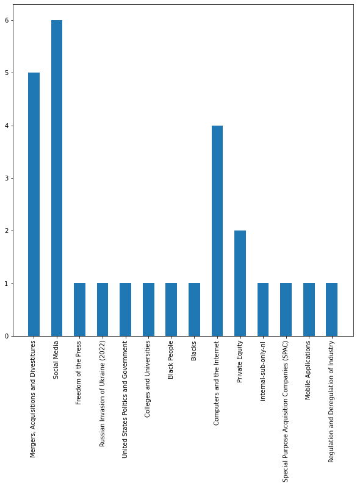

```python
pd.set_option('display.max_colwidth', None)

plt.figure(figsize=(10,10))
ax = plt.axes()
ax.set_xticklabels(counts.keys(), rotation=90)

plt.bar(counts.keys(), counts.values(), width=.5)
plt.show()
```

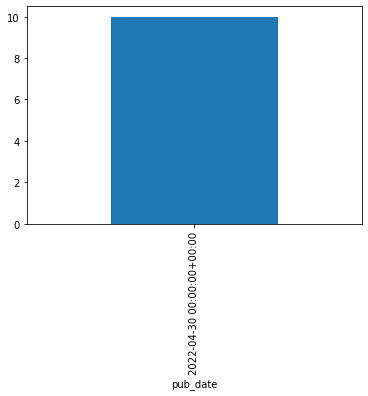

```python
#Number of articles published each day
df.resample('M', on='pub_date').size().plot(kind='bar')
```

Below I will be plotting the various types of news categories (using news_desk) as a pie chart. The percentage is displayed in the chart.

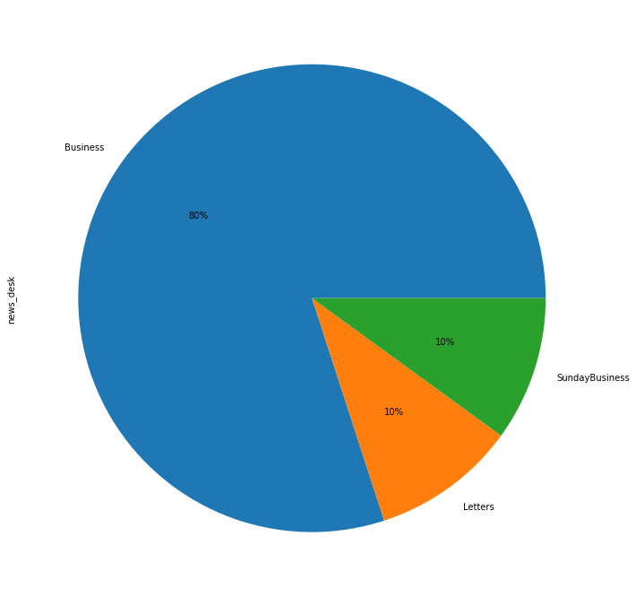

```python
#plot percentage inside chart
plt.figure(figsize=(12,12))
df['news_desk'].value_counts().plot(kind='pie', autopct='%1.0f%%')
```

Here I listed how many articles have identified twitter as a bussiness. As you can see that roughly 80% articles written in 2022 have identified twitter as a bussiness. Some articles just talk about unrelated topics that don't really have anything to do with twitter.

# Part 2 : News Sentiment Analysis

Here I would have done the news sentiment analysis, but due to time constraints, I was not able to finish. I would have used the Natural Language Toolkit (NLTK) python package. This could be installed at http://www.nltk.org/install.html. Once installed you would open the Python command line and run nltk.download(). This is used to grab NLTK's databases.

Once installed I would have used the built-in sentiment analyzer and ranked each news story as a positive, negative, or neutral.